# Mediterranean Refugee Deaths

Rachit Kinger

8 Jun 2018

## Exploring the data

```r
loadPackages <- function() {
  library(dplyr)
  library(ggplot2)
  library(knitr)
  library(DT)
  library(lubridate)
  library(gganimate)
}
suppressPackageStartupMessages(loadPackages())
```

**NOTE**: Although the original source of this data is [Missing Migrants Project](https://missingmigrants.iom.int/) I received this file from Jonathan Miller via the wikitribune-community on slack.

Before making any final conclusions from this analysis please take a look at the methodology on how this data was collected. Here are a few important points to note regarding methodology:

- Only those migrants who died in a country different from their residence have been recorded
- If a corpse was found, some inferences were made based on features of the corpse, where the corpse was found, etc.
- The count excludes deaths that occur in immigration detention facilities, during deportation, or after forced return to a migrant’s homeland, as well as deaths more loosely connected with migrants´ irregular status, such as those resulting from labour exploitation. Deaths in refugee camps are included
- Data collection: “…data are relayed from relevant national authorities to IOM field missions, who then share it with the Missing Migrants Project team. Data are also obtained by IOM and other organizations that receive survivors at landing points in Italy and Greece. IOM and UNHCR also regularly coordinate to validate data on missing migrants in the Mediterranean.”

Also note that the original data has one other piece of information called, *Source quality*, that is currently not found on the file used for this analysis. Source quality is a number assigned to each incident and ranges from 1 to 5, with 5 having the highest quality.

```r
raw <- readr::read_csv("Mediterranean refugee deaths.csv")
```

```r
# convert date into correct data type
raw$`Reported Date` <- lubridate::mdy(raw$`Reported Date`)
```

**Time period of analysis**

```r
range(raw$`Reported Date`)
```

```
[1] "2014-01-19" "2018-05-26"
```

Looking at total incidents, and then breakdown by route, gender, adult/children, etc.

Total incidents in data set = 810

```r
raw %>%
  select(`Number Dead`, `Number Missing`, `Number of Survivors`,
         `Number of Females`, `Number of Males`, `Number of Children`) %>%
  summarise_all(funs(sum(., na.rm = TRUE))) %>%
  kable()
```

```
| Number Dead| Number Missing| Number of Survivors| Number of Females| Number of Males| Number of Children|
|-----------:|--------------:|-------------------:|-----------------:|---------------:|------------------:|
|        5556|          10447|               34698|               642|            1522|                578|
```

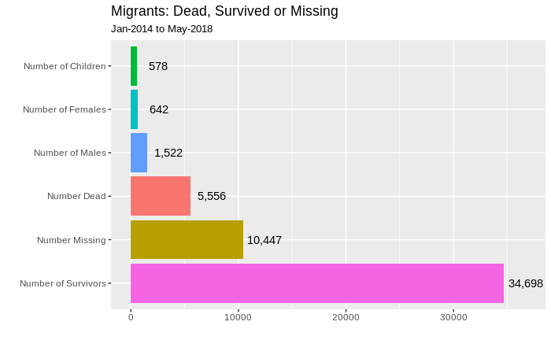

```r
raw %>%
  select(`Number Dead`, `Number Missing`, `Number of Survivors`,
         `Number of Females`, `Number of Males`, `Number of Children`) %>%
  summarise_all(funs(sum(., na.rm = TRUE))) %>%
  tidyr::gather(key = Name, value = Number) %>%
  ggplot() +
  geom_col(mapping = aes(x = reorder(Name, -Number), y = Number, fill = Name), position = "dodge") +
  geom_text(mapping = aes(x = Name, y = Number, label = scales::comma(Number)), nudge_y = 2000 ) +
  coord_flip() +
  theme(legend.position= "", legend.title=element_blank()) +
  xlab("") + ylab("") +
  ggtitle("Migrants: Dead, Survived or Missing",
          subtitle = "Jan-2014 to May-2018")
```

There is little data on gender and age of migrants mising or dead. Where reported the number of females/males/children reports the numbers on missing or dead migrants.

```r
raw %>%
  group_by(`Reported Year`) %>%
  select(`Reported Year`, `Number Dead`, `Number Missing`, `Number of Survivors`,
         `Number of Females`, `Number of Males`, `Number of Children`) %>%
  summarise_all(funs(sum(., na.rm = TRUE)))
```

```
# A tibble: 5 x 7
  `Reported Year` `Number Dead` `Number Missing` `Number of Survivors`
            <int>         <int>            <int>                 <int>
1            2014           725             2558                  4908
2            2015          2176             1607                  7328
3            2016          1484             3659                 16216
4            2017           936             2203                  5316
5            2018           235              420                   930
# ... with 3 more variables: `Number of Females` <int>, `Number of
#   Males` <int>, `Number of Children` <int>
```

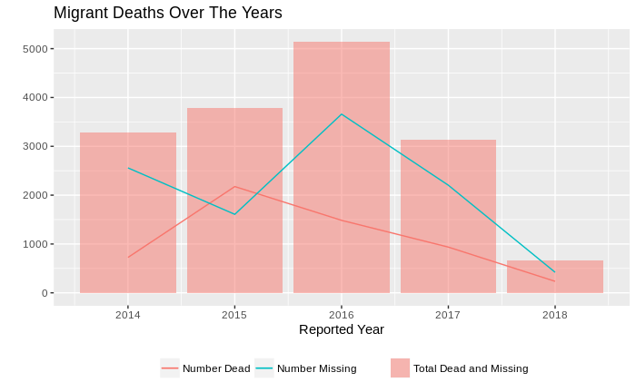

```r
raw %>%
  group_by(`Reported Year`) %>%
  select(`Reported Year`, `Number Dead`, `Number Missing`, `Number of Survivors`,
         `Number of Females`, `Number of Males`, `Number of Children`) %>%
  summarise_all(funs(sum(., na.rm = TRUE)))  %>%
  ggplot(aes(x = `Reported Year`)) +
  geom_col(aes(y = `Number Dead` + `Number Missing`, fill = "Total Dead and Missing"), alpha = 0.5) +
  geom_line(aes(y = `Number Dead`, colour = "Number Dead")) +
  geom_line(aes(y = `Number Missing`, colour = "Number Missing")) +
  theme(legend.position="bottom", legend.title=element_blank()) +
  ggtitle("Migrant Deaths Over The Years") +
  ylab("")
```

```r
NA
```

The total migrant deaths/missing seemed to have peaked in 2016 and is on a downward trend. Strangely there were more deaths reported than missing in the year 2015. As the deaths and missing increased till 2016, so did the number of survivors (16,216). We know that 2016 was the peak for the year of migration across the Mediterranean.

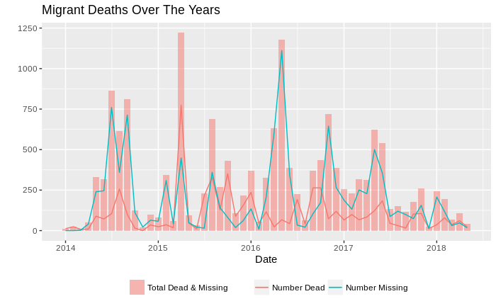

```r
# monthly pattern
raw %>%
  group_by(`Reported Year`, `Reported Month`) %>%
   select(`Reported Year`, `Number Dead`, `Number Missing`, `Number of Survivors`,
         `Number of Females`, `Number of Males`, `Number of Children`) %>%
  summarise_all(funs(sum(., na.rm = TRUE))) %>%
  mutate(Date = lubridate::dmy(paste0("01-",`Reported Month`, "-",`Reported Year`))) %>%
  mutate(Season = if_else(`Reported Month` %in% c("Jan", "Feb", "Mar"), "Winter",
                          if_else(`Reported Month` %in% c("Apr", "May", "Jun"), "Spring",
                                  if_else(`Reported Month` %in% c("Jul", "Aug", "Sep"), "Summer", "Autumn")))) %>%
  ggplot(aes(x = `Date`)) +
  geom_col(aes(y = `Number Dead` + `Number Missing`, fill = "Total Dead & Missing"), alpha = 0.5) +
  geom_line(aes(y = `Number Dead`, colour = "Number Dead")) +
  geom_line(aes(y = `Number Missing`, colour = "Number Missing")) +
  theme(legend.position="bottom", legend.title=element_blank()) +
  ggtitle("Migrant Deaths Over The Years") +
  ylab("")
```